# Sesion 15 - Selección de Variables Parte 1/3

Juan Carlos Martínez-Ovando

Maestría en Ciencia de Datos

Primavera 2019

# 1 Motivacion

## 1.1 Objetivo de la seccion tematica

- Estudiar los fundamentos matematicos, implementacion e intrepretacion del problema de seleccion de variables en el contexto de regresion.
- Entender que el problema de seleccion de variables involucra un problema de comparacion de modelos.
- Entender las soluciones en dos contextos inferenciales: frecuentista y bayesiano.

## 1.2 Plan tematico

Dividiremos el estudio de este problema en tres partes:

1. Comparacion y seleccion de modelos
2. Seleccion de variables en el contexto de regresion
3. Seleccion de variables en el contexto de regresion binaria (y modelos lineales generalizados, en general)

> **Todo esto con miras a enternder el problema y poder resolver el en contexto de analisis de datos categoricos, como veremos adelante en el curso.**

## 1.3 Objetivo de la sesion

- Entender el planteamiento y solucion del problema de comparacion y seleccion de modelos.

# 2 Comparacion de modelos

## 2.1 Contexto

Estudiaremos el problema de comparacion de modelos en un contexto general.

Para esto, consideremos:

1. $Y$ es una variable generica para la cual podemos acceder a un conjunto de $\text{datos}=\{y_1,\ldots, y_n\}$
2. el desconocimiento acerca de $Y$ es drescrito por $M$ **modelos alternativos**, siendo
   $$\mathcal{P} =
   \{P_1,\ldots,P_M\},$$
   la coleccion de modelos, y
   $$P_m=\{f_m(y|\theta_m): \theta_m\in\Theta_m\},$$
   donde $f_m()$ denota un modelo de probabilidad con una estructura particular para el modelo $m$, y $\theta_m$ su correspondiente parametro.

## 2.2 Observaciones

En un contexto general, podemos considerar que los modelos en $\mathcal{P}$ pueden ser de dos tipos:

1. **Anidados:-** Cuando los $f_m(y|\theta_m)=f(y|\theta_m)$, para todo $m$; *i.e.* todos los modelos en $\mathcal{P}$ tienen la ***misma forma estructural, difiriendo en sus parametros*
2. **No anidados:-** Cuando los modelos $f_m(y|\theta_m)$ son estructuralmente distintos para diferentes $m$.

## 2.3 Ejemplos

1. **Anidados:-** En el contexto de regresion, podemos pensar en que $Y$ este relacionada con una coleccion $m$ de covariables,
   $$X_1^{(m)},\ldots,X^{(m)}_{p^{(m)}},$$
   seleccionadas de entre un conjunto
   $$X_1,\ldots,X_p$$
   de posibles covariables, con
   $$p^{(m)}<p.$$

En este caso, bajo el supuesto de normalidad, tendriamos que
$$f(y|\boldsymbol{x}^{(m)},\theta_m) =
\text{N}(y|\mu_{x,m},\sigma_m^2)$$
donde
$$\mu_{x,m}=\theta_m'\boldsymbol{x}^{(m)},$$
para $m=1,\ldots,M$.

2. **No anidados:-**

Pensemos que $M=2$ y que $Y$ toma valores en la recta real, entonces $\mathcal{P}$ contemplaria dos alternativas,
$$\begin{eqnarray}
P_1: & Y\sim & \text{N}(y|\mu,\sigma^2)\nonumber \\
P_2: & Y\sim & \text{Ca}(y|\mu,\gamma).\nonumber.
\end{eqnarray}$$

En este caso, los parametros son
$$\begin{eqnarray}
\theta_1 & = & (\mu,\sigma^2)\nonumber \\
\theta_2 & = & (\mu,\gamma).\nonumber
\end{eqnarray}$$

# 3 Ilustracion

Consideramos el caso de **modelos no anidados** para $\mathcal{P}$.

## 3.1 Datos simulados

Consideremos que
$$y_1,\ldots,y_n,$$
son datos simulados de tres tipos de distribuciones:
$$\begin{eqnarray}
P_1: & Y\sim &\text{N}(y|0,\tau^2)\nonumber \\
P_2: & Y\sim & \text{t}_{\nu}(y|0,\tau^2)\nonumber \\
P_3: & Y\sim & \text{Mix-N}(y|0,w,1,\tau^2)\nonumber
\end{eqnarray}$$

Generamos una bandera de identificacion, para el origen de los datos, por cuestiones de control.

```r
true.model="gaussian"
#true.model="student"
true.model
```

```
## [1] "gaussian"
```

Desplegamos los datos simulados del modelo $P_1$ (`modelo gaussiano`). La variable $n$ denota el numero de datos simulados.

```r
if(!require('invgamma')){install.packages("invgamma")}
```

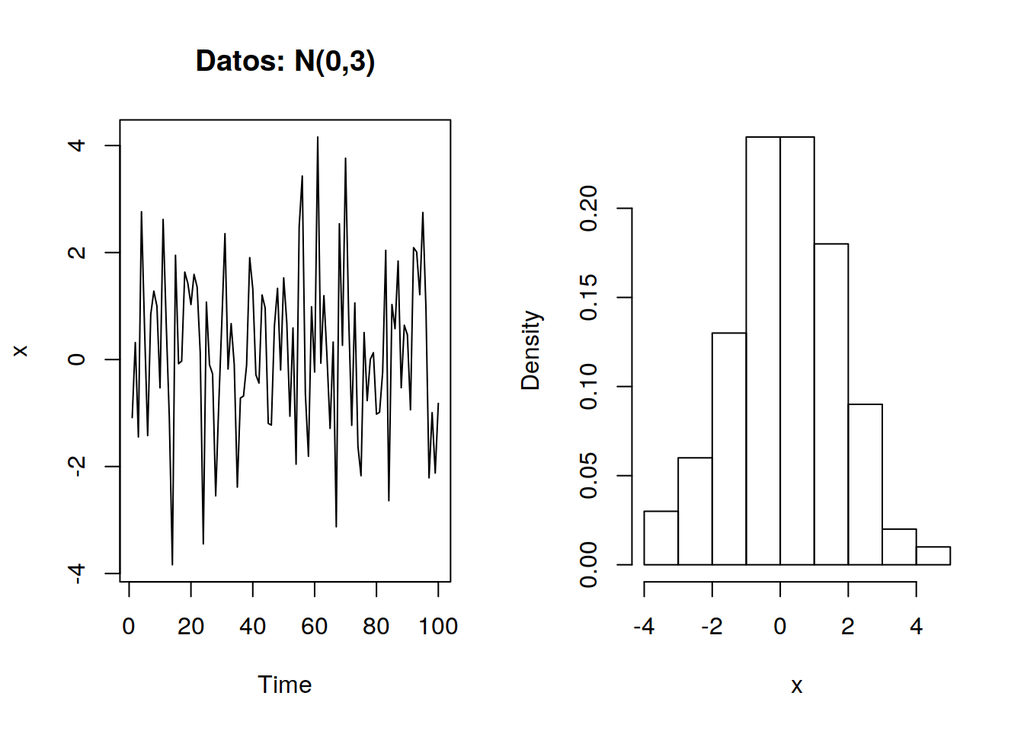

```r
library("invgamma")

set.seed(1)
true.model="gaussian"
#true.model="student"
n <- 100
tau2.true <- 3
nu.true <- 3
if(true.model=="gaussian"){
  x <- rnorm(n,0,sqrt(tau2.true))
}else{
  x <- sqrt(tau2.true)*rt(n,df=nu.true)
}
sumx2 = sum(x^2)

if (true.model=="gaussian"){
  par(mfrow=c(1,2))
  ts.plot(x,main=paste("Datos: N(0,",tau2.true,")",sep=""))
  hist(x,main="",prob=TRUE)
}else{
  par(mfrow=c(1,2))
  ts.plot(x,main=paste("Datos: Student's t(0,",tau2.true,",",nu.true,")",sep=""))
  hist(x,main="",prob=TRUE)
}
```

## 3.2 Aprendizaje en P.1

En el caso en que los datos,
$$y_1,\ldots,y_n,$$
tengan asociadas variables aleatorias `iid`, con
$$Y\sim \text{N}(y|0,\tau^2),$$
donde
$$\tau^2 \sim \text{GaI}(c0,d0),$$
con $c0$ y $d0$ `hiperparametros` conocidos (inducidos por `informacion suplementaria`).

**En este caso, el parametro $\theta_1=(\tau^2)$ solamente.**

- En partcular, esperificaremos $d_0=c_0+1$, de manera que la `moda suplementaria` para $\tau^2$ sea igual a $1$
- El valor $c0=4$ corresponde a `informacion suplementaria no informativa`, con desviaciones en el orden $1.2$.

**Nota:-** Recordemos que $\mathbb{E}_{\text{GaI}}(\tau^2)=d0/(c0-1)$, y $\text{moda}(\tau^2)=d_0/(c_0+1)$, con $\text{var}(\tau^2)=d_0^2/(c_0-1)^2(c_0-2))$.

**MLE:-** Es relativamente sencillo de obtener que
$$\hat{\tau}^2_{mle}=\sum_{i=1}^n y_i^2/n,$$
corresponde al `estimador puntual muestral (datos)` de $\tau^2$.

```r
tau2.mle <- sumx2/n
tau2.mle
```

```
## [1] 2.431653
```

```r
N <- 1000
tau2s <- seq(0.001,20,length=N)
like <- (2*pi*tau2s)^(-n/2)*exp(-0.5*sumx2/tau2s)

c0 <- 4
d0 <- c0+1
prior <- dinvgamma(tau2s,c0,d0)

logpred.model1 <- log(sum(like*prior*(tau2s[2]-tau2s[1])))
logpred.model1
```

```
## [1] -188.3251
```

```r
c1 <- c0+n/2
d1 <- d0+sumx2/2
posterior <- dinvgamma(tau2s,c1,d1)

tau2.mode1 = d1/(c1+1)
tau2.mode1
```

```
## [1] 2.301503
```

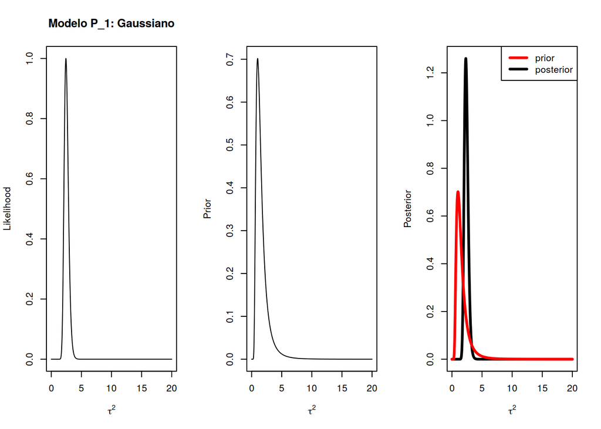

```r
par(mfrow=c(1,3))
plot(tau2s,like/max(like),xlab=expression(tau^2),ylab="Likelihood",type="l")
title("Modelo P_1: Gaussiano")
plot(tau2s,prior,xlab=expression(tau^2),ylab="Prior",type="l")
plot(tau2s,posterior,xlab=expression(tau^2),ylab="Posterior",type="l",lwd=3)
lines(tau2s,prior,col=2,lwd=3)
legend("topright",legend=c("prior","posterior"),col=2:1,lty=1,lwd=3)
```

## 3.3 Aprendizaje en P.2

en este caso, suponemos que
$$x_1,\ldots,x_n$$
tienen asociadas variables aleatorias `iid`, con
$$Y\sim \text{t}_{\nu}(0,\tau^2),$$
donde
$$\tau^2 \sim \text{Gai}(e0,f0),$$
con $e0$ y $f0$ `hiperparametros suplementarios` conocidos.

- En particular, consideraremos $f0=e0+1$, de manrea que `suplementariamente` la moda de $\tau^2$ sea igual a $1$.
- El parameto $e0=4$ define una `informacion suplementaria vaga/no informativa`, con una desviacion estandar sercana a $1.2$.
- Para $\nu$, empleamos una version discretizada propuesta por Juarez & Steel (2010), con $k=10$, i.e.
  $$p(\nu) \propto 2 k \nu/((\nu+k)^3),$$
  para
  $$\nu \in \{1,\cdots,50\}.$$

```r
e0 <- 4
f0 <- e0+1
numax <- 50
N <- 100
tau2s <- seq(0.001,20,length=N)
nus <- 1:numax

k <- 10

like <- matrix(0,N,numax)
prior <- matrix(0,N,numax)
normnu <- sum(2*k*nus/((nus+k)^3))
i <- 1
for(i in 1:N){
  for(j in 1:numax){
    like[i,j] <- prod(dt(x/sqrt(tau2s[i]),nus[j])/sqrt(tau2s[i]))
    prior[i,j] <- dinvgamma(tau2s[i],e0,f0)*2*k*nus[j]/((nus[j]+k)^3)/normnu
  }
}

logpred.model2 <- log(sum(like*prior*(tau2s[2]-tau2s[1])*(nus[2]-nus[1])))
logpred.model2
```

```
## [1] -188.4944
```

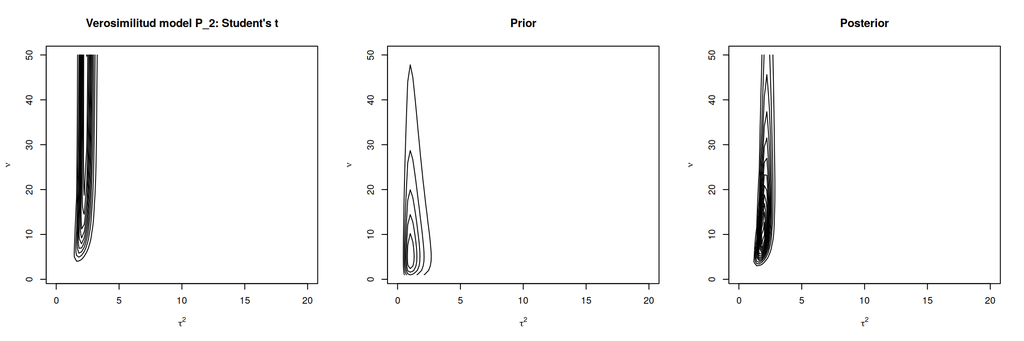

```r
like <- like/max(like)
post <- prior*like

par(mfrow=c(1,3))
contour(tau2s,nus,like,xlab=expression(tau^2),ylab=expression(nu),drawlabels=FALSE)
title("Verosimilitud model P_2: Student's t")
contour(tau2s,nus,prior,xlab=expression(tau^2),ylab=expression(nu),drawlabels=FALSE)
title("Prior")
contour(tau2s,nus,post,xlab=expression(tau^2),ylab=expression(nu),drawlabels=FALSE)
title("Posterior")
```

```r
ind=1:N
tau2.mode2 = tau2s[ind[apply(post==max(post),1,sum)==1]]
ind=1:numax
nu.mode2 = nus[ind[apply(post==max(post),2,sum)==1]]

c(tau2.mode2,nu.mode2)
```

```
## [1] 1.819091 9.000000
```

## 3.4 Aprendizaje en P.3

En este caso, suponemos que,
$$y_1,\ldots,y_n,$$
tienen asociadas variables aleatorias `iid`, con distribucion dada por la mezcla de dos distribuciones gaussianas,
$$f_3(y|w,1,\tau^2)=w \text{N}(y|0,1)+(1-w)\text{N}(y|0,\tau^2),$$
con
$$\tau^2 \sim \text{GaI}(a0,b0),$$
con $a0$ y $b0$ `hiperparametros suplementarios` conocidos.

- Definimos, en este caso, $b0=a0+1$ de manera que la `moda suplementaria` sea igual a $1$, y
- El parametro $a0=4$ define una `informacion suplementaria vaga/no informativa` con desviacion estandar cercaca a $1.2$.
- Suponemos que $w$ varia uniformemente en el conjunto discreto:
  $$\{0,0.01,0.02,\ldots,1.0\}.$$

```r
a0 <- 4
b0 <- a0+1
N <- 100
tau2s <- seq(0.001,20,length=N)
ws <- seq(0,1,length=N)
like <- matrix(0,N,N)
prior <- matrix(0,N,N)
i <- 1
for (i in 1:N){
  j <- 1
  for (j in 1:N){
    like[i,j] <- prod(ws[j]*dnorm(x)+(1-ws[j])*dnorm(x,0,sqrt(tau2s[i])))
    prior[i,j] <- dinvgamma(tau2s[i],a0,b0)*(1/N)
  }
}

logpred.model3 <- log(sum(like*prior*(tau2s[2]-tau2s[1])*(ws[2]-ws[1])))
logpred.model3
```

```
## [1] -193.9013
```

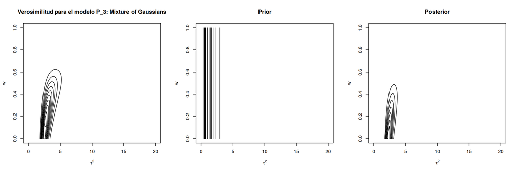

```r
like <- like/max(like)
post <- prior*like

par(mfrow=c(1,3))
contour(tau2s,ws,like,xlab=expression(tau^2),ylab=expression(w),drawlabels=FALSE)
title("Verosimilitud para el modelo P_3: Mixture of Gaussians")
contour(tau2s,ws,prior,xlab=expression(tau^2),ylab=expression(w),drawlabels=FALSE)
title("Prior")
contour(tau2s,ws,post,xlab=expression(tau^2),ylab=expression(w),drawlabels=FALSE)
title("Posterior")
```

```r
ind=1:N
tau2.mode3 = tau2s[ind[apply(post==max(post),1,sum)==1]]
w.mode3    = ws[ind[apply(post==max(post),2,sum)==1]]
c(tau2.mode3,w.mode3)
```

```
## [1] 2.223111 0.000000
```

## 3.5 Comparacion de modelos

Habiendo estimado los tres modelos con los `mismos datos`, $y_1\ldots,y_n$, podemos **comparar los tres modelos entre si**, con base en su `adecuacion` con los `datos` a traves del **factor de Bayes (o Bayes factor, BF).**

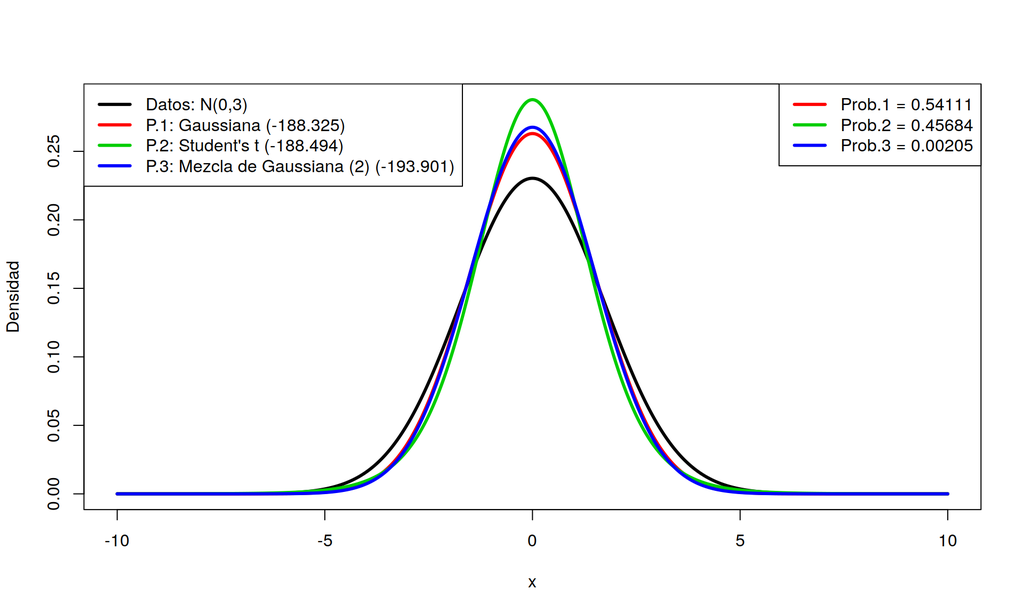

```r
logpreds <- c(logpred.model1,logpred.model2,logpred.model3)
post.model <- round(exp(logpreds)/sum(exp(logpreds)),5)

xxx <- seq(-10,10,length=1000)
if (true.model=="gaussian"){
  den.true <- dnorm(xxx,0,sqrt(tau2.true))
}else{
  den.true <- dt(xxx/sqrt(tau2.true),df=nu.true)/sqrt(tau2.true)
}
den1 <- dnorm(xxx,0,sqrt(tau2.mode1))
den2 <- dt(xxx/sqrt(tau2.mode2),df=nu.mode2)/sqrt(tau2.mode2)
den3 <- w.mode3*dnorm(xxx)+(1-w.mode3)*dnorm(xxx,0,sqrt(tau2.mode3))
ltrue <- log(den.true)
lden1 <- log(den1)
lden2 <- log(den2)
lden3 <- log(den3)

par(mfrow=c(1,1))
plot(xxx,den.true,type="l",ylab="Densidad",xlab="x",ylim=range(den.true,den1,den2,den3),lwd=3)
lines(xxx,den1,col=2,lwd=3)
lines(xxx,den2,col=3,lwd=3)
lines(xxx,den3,col=4,lwd=3)
if(true.model=="gaussian"){
  legend("topleft",legend=c(
paste("Datos: N(0,",tau2.true,")",sep=""),
paste("P.1: Gaussiana (",round(logpred.model1,3),")",sep=""),
paste("P.2: Student's t (",round(logpred.model2,3),")",sep=""),
paste("P.3: Mezcla de Gaussiana (2) (",round(logpred.model3,3),")",sep="")),col=1:4,lty=1,lwd=3)
}else{
  legend("topleft",legend=c(
paste("Datos: Student's t(0,",tau2.true,",",nu.true,")",sep=""),
paste("P.1: Gaussian (",round(logpred.model1,3),")",sep=""),
paste("P.2: Student's t (",round(logpred.model2,3),")",sep=""),
paste("P.3: M2 Gaussians (",round(logpred.model3,3),")",sep="")),col=1:4,lty=1,lwd=3)
}
legend("topright",legend=c(
paste("Prob.1 = ",post.model[1],sep=""),
paste("Prob.2 = ",post.model[2],sep=""),
paste("Prob.3 = ",post.model[3],sep="")),col=2:4,lty=1,lwd=3)
```

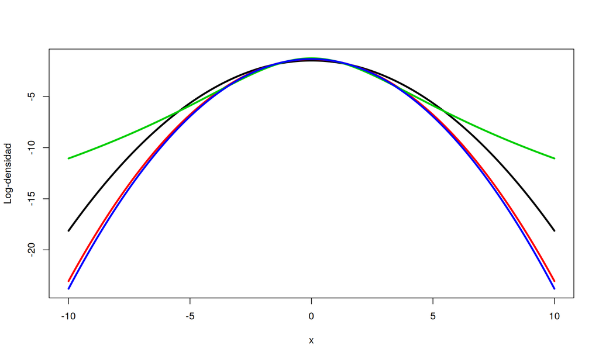

```r
par(mfrow=c(1,1))
plot(xxx,ltrue,type="l",ylab="Log-densidad",xlab="x",ylim=range(ltrue,lden1,lden2,lden3),lwd=3)
lines(xxx,lden1,col=2,lwd=3)
lines(xxx,lden2,col=3,lwd=3)
lines(xxx,lden3,col=4,lwd=3)
```

# 4 Modelo de regresión

## 4.1 Caso univariado (regresion multiple)

En este caso, la variable de respuesta es escalar, i.e. $Y\in \Re$, y $X=(X_1,\ldots,X_p)$ con $p$ variables explicativas (covariables), de tal forma que

$$Y|X=x \sim N(y|x'\beta,\sigma)$$
es la distribucion condicional donde
$$\mathbb{E}(Y|x)=x'\beta.$$

## 4.2 Observaciones

Cuando tenemos varias observaciones, $i=1,\ldots,n$, el modelo es expresado como
$$Y_i|X_i=x_i \sim N(y|x_i'\beta,\sigma),$$
o equivalentemente en su forma matricial como
$$\boldsymbol{Y}|\boldsymbol{X}=\boldsymbol{x} \sim N_n\left(y|\boldsymbol{X}'\beta,\sigma\boldsymbol{I}\right).$$

## 4.3 Aprendizaje estadistico

Cuando trabajamos con el modelo de regresion multiple, la *identificacion* o *estimacion* de $\beta$, obtenida mediante el paradigma frecuentista o bayesiano, se basa en encontrar el valor de $\beta$ que maximice (en cierta forma) la verosimilutid
$$\text{lik}
\left(\beta,\sigma|\boldsymbol{y},\boldsymbol{X}\right)
\propto
\sigma^{-n/2}
\exp\left\{-\frac{1}{2 \sigma}(\boldsymbol{y}-\boldsymbol{X}'\beta)'(\boldsymbol{y}-\boldsymbol{X}'\beta)\right\},$$
o, equivalentemente, mediante la minimizacion de una funcion de perdida asociada (errores cuadraticos, es el caso general), i.e.
$$\text{L}
\left(\beta,\sigma|\boldsymbol{y},\boldsymbol{X}\right)
\propto
\exp \left\{(\boldsymbol{y}-\boldsymbol{X}'\beta)' (\boldsymbol{y}-\boldsymbol{X}'\beta)\right\},$$
en cuyo caso tenemos varios resultados para $\beta$.

## 4.4 Casos relevantes

1. Cuando $n>>p$ y $\boldsymbol{X}$ de dimension $n\times p$ es de **rango completo** (i.e. ninguna columna es una combinacion lineal de las otras), entonces el estimados de $\beta$ estara en funcion de
   $$(\boldsymbol{X}'\boldsymbol{X})^{-1}\boldsymbol{X}'\boldsymbol{y},$$
   dependiendo del paradigma inferencia adoptado.
2. Cuando $n>>p$ pero $\boldsymbol{X}$ de dimension $n\times p$ no es o casi no es de **rango completo** (i.e. una o varias columnas son combinaciones lienales de otras, o casi una o varias columnas son combinaciones lineales de las restantes, respectivamente), entonces $(\boldsymbol{X}'\boldsymbol{X})^{-1}$ no existe de manera **unica**, por lo que varios valores estimadores de $\beta$ existiran, y de hehco varios valores de $\beta_j$s seran redundantes (i.e. cercanos a cero o con varianzas extraordinariamente grandes).
3. Cuando $p>n$ tendremos que tratarlo particularmente… (mas adelante en el curso, con relaci'on al modelo `FA`).

## 4.5 Seleccion de variables

Cuando $Y$ es la variable de respuesta, estaremos interesados en encontras una `seleccion/subgrupo ad-hoc` de `todas` las covariables disponibles,
$$X_1,\ldots,X_p,$$
que sea particularmente relevante para describir la variabilidad en $Y$.

> Incluir todas las $p$ covariables puede distorcionar la relacion (en terminos del aprendizaje estadistico).

Veremos en la siguiente sesion que podemos crear `sub-grupos` de covariables
$$X^{(m)}_1,\ldots,X^{(m)}_{p_m},$$
para
$$m=1,\ldots,M,$$
con
$$M=2^p.$$

> No siempre consideraremos las $2^p$ combinaciones, i.e.
> $$M \leq 2^p.$$

> El numero de subselecciones puede ser extenuante cuand $p$ es `grande`. Cuidado!!!

Cada `subgrupo de covariables`, $m$, definira un `modelo anidado` de regresion, donde
$$Y|X^{(m)}_1,\ldots,X^{(m)}_{p_m} \sim \text{N}(y|\theta_m'\boldsymbol{x}^{(m)},\tau_m^2).$$

**El proposito, sera el definir un `procedimiento automatizado` para identificar cual `subgrupo de covariables` es mas informativo para $Y$.**

# 5 Comentarios

- El **BF** es una medida de comparacion de modelos `1 a 1`. Sin embargo, es utila para comparar varios modelos entre si, estableciendo todas las comparaciones `1 a 1` posibles.
- La felxibilidad del **BF** reside en que no restringe que la forma estructural de los modelos sea la misma en $\mathcal{P}$.
- Se ha empleado con bastante exito para comparar y seleccionar **modelos anidados**. Esto lo veremos, en particular, en el contexto de `seleccion de variables en regresion`.